# STAT 209 Lab 15: Reverse Engineering a Professional Writeup

# Integrating SQL with R and `ggplot2`

## SQL vs `dplyr`

Now that you (are on your way to) know(ing) two different data wrangling languages (`dplyr` and `SQL`), it’s worth spending a minute thinking about their relative strengths and weaknesses. Here are a few strengths of each one:

`dplyr`

- Runs on the same computer you’re working on
- Has a “functional programming” style: Each wrangling verb has a clear input and output (whether this is a strength depends on your attitude toward functional programming, I suppose)
- Is integrated into the larger `tidyverse`
- Is more flexible: can combine standard verbs with arbitrary R code, incorporate code in custom functions, etc

`SQL`

- Is more efficient for large datasets
- Code reads (sort of) like English sentences (this is also a matter of taste; the code is probably ‘easier on the eyes’ than R code, but I find it harder to pull apart than the functional style of R; but… your mileage may vary)
- Is more widely used in industry outside data science specifically (though R and the tidyverse have gotten far more widely used in the last few years)

There are two big reasons we can’t rely exclusively on SQL, however:

- it doesn’t support plotting
- it doesn’t support statistical modeling

So if we want to do more than show some tables, we need to be able to pass the results of our SQL queries back into R, so we can create graphs and (though we’re not focusing on this in this class) models.

## Goal of this lab

Use SQL together with `ggplot` to produce visualizations from large datasets.

In particular, we will try to verify the following claim from the FiveThirtyEight article [here](https://fivethirtyeight.com/features/fastest-airlines-fastest-airports/):

“In 2014, the 6 million domestic flights the U.S. government tracked required an extra 80 million minutes to reach their destinations. The majority of flights – 54 percent – arrived ahead of schedule in 2014. (The 80 million minutes figure cited earlier is a net number. It consists of about 115 million minutes of delays minus 35 million minutes saved from early arrivals.)”

as well as to reproduce the graphic therein (shown below).

[figure not shown]

Figure: Reproduced from MDSR p. 291

## Setup Boilerplate and Reference (Repeated from Labs 13-14)

We need to load packages and set up a connection to the server again.

**Code:**

```r
library(dbplyr)  ## Note the 'b'; this is not dplyr
library(mdsr)    ## Package for our book
library(RMySQL)  ## Standard R/SQL interface package
db <- dbConnect_scidb("airlines")
```

For convenience here is the list of basic verbs again:

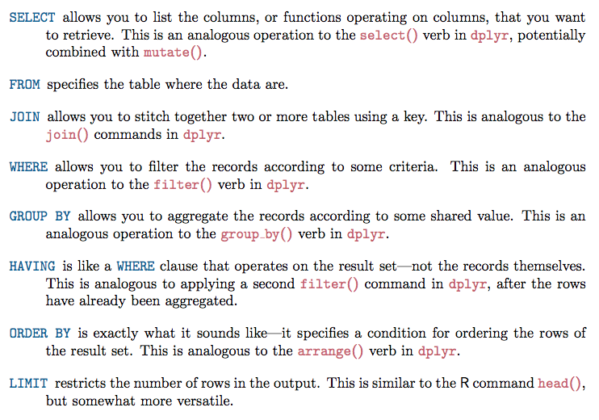

Image Source: Baumer et al. *Modern Data Science with R*.

**Remember:** Verbs lower in the list must appear *after* verbs higher in the list when constructing queries.

Here’s the `dplyr` to `SQL` translation summary again:

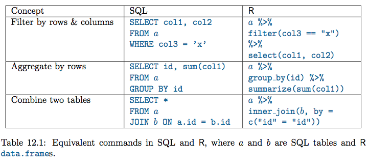

Image Source: Baumer et al. *Modern Data Science with R*

And, it bears repeating, in all caps:

**IMPORTANT: ALWAYS `LIMIT` YOUR QUERIES, LEST YOU TRY TO FETCH HUNDREDS OF MILLIONS OF RECORDS AND BREAK EVERYTHING FOR EVERYONE!**

One last reminder: to designate a code chunk “SQL”, use `{sql connection=db}` in the chunk options (where `db` is whatever you named your connection in a previous R code chunk) in place of the `r` that is usually there.

## Extracting the necessary summary statistics

1. Before diving into writing any queries, examine the quote and the graph together with your group and work together to sketch out what the summarized data table(s) should look like to verify the quote and reproduce the graph. Note that flights are only classified as a “late arrival” if the delay is 15 minutes or more. What are the rows, what columns are needed, which of these correspond to columns in the `flights` data, etc.? Remember you can use use `DESCRIBE` in an SQL chunk to see an overview of the columns. For columns that represent summary statistics, how can these be computed? Write down the computation steps in sentences; not in code yet. Working backwards like this can be a good way to approach a wrangling+visualization problem.

##### OUTLINE OF APPROACH

```r
db <- dbConnect_scidb("airlines")
```

2. Take the `flights` dataset, and write an SQL query to calculate the necessary summary information. To save computing strain, just use the flights that took place on your birthday in 2014, rather than all of 2014, and multiply each variable (that isn’t a percentage) by 365 to extrapolate to the whole year (there are of course seasonal differences in flight delays, so this is not a representative sample, so we shouldn’t expect extremely similar results to the FiveThirtyEight article). **A tip:** you can use commands of the form `if(<condition>, <value if true>, <value if false>)` in SQL to create a variable that has one value if a condition is met and another value if it isn’t (the angle brackets indicate placeholders, and shouldn’t actually be typed). **Note:** The result should just be one row, but include a `LIMIT` clause anyway, just in case the result isn’t what you intend.

##### SOLUTION

3. Revise your query to add 270 minutes to each canceled flight. **Hint:** Cancelled flights show an arrival delay of 0 as-is, so you can modify your `if()` statement that adds up the minutes late, tallying 270 for a cancelled flight instead of zero.

##### SOLUTION

Now let’s create the dataset for the graph. We’re going to need to pull the results into R, but let’s first write the query in SQL to confirm that we get what we want.

4. Write an SQL query to produce a data table with the summary statistics needed for the graph. Don’t worry about the `pivot_longer()` step that we’ll need to get the data into the “tidy” format; we’ll do that in R later. **Hint:** for the labels, you’ll want the `name` field from the `carriers` data table. **Note:** that the graph is sorted in descending order by percentage of short delays.

## Bringing the result set into R

We’re now done with the SQL part of the process!

Now that we have a small dataset, we can turn it into an R data frame and do our finishing wrangling touches in `dplyr` and our visualization in `ggplot2`.

5. Once you have your SQL query working, create an R object that contains the text of the query as one big quoted string (you can include the line breaks). You can call it whatever you want; I will refer to this variable below as `query`.

##### SOLUTION

6. Having defined the `query` string, create an R data frame that contains the relevant information with `db %>% dbGetQuery(query) %>% collect()`. The use of `collect()` here brings the actual data from the table into memory; not just a pointer to a “view” of the data on the remote server, so don’t do this until you know that your query produces the small result set you want.